# Week 4 Project - Practical Machine Learning - Prediction Assignment

### Januaray 31, 2018

## Practical Machine Learning Project : Prediction Assignment Writeup

## Human Activity Recognition

Read more: http://groupware.les.inf.puc-rio.br/har#ixzz55kjniTbw

## 2. Background

- Using devices such as Jawbone Up, Nike FuelBand, and Fitbit it is now possible to collect a large amount of data about personal activity relatively inexpensively. These type of devices are part of the quantified self movement - a group of enthusiasts who take measurements about themselves regularly to improve their health, to find patterns in their behavior, or because they are tech geeks. One thing that people regularly do is quantify how much of a particular activity they do, but they rarely quantify how well they do it. In this project, your goal will be to use data from accelerometers on the belt, forearm, arm, and dumbell of 6 participants. They were asked to perform barbell lifts correctly and incorrectly in 5 different ways. More information is available from the website here: http://groupware.les.inf.puc-rio.br/har (see the section on the Weight Lifting Exercise Dataset). Read more: http://groupware.les.inf.puc-rio.br/har#ixzz3xsbS5bVX

## 3. Dataset Overview

- The training data for this project are available here: https://d396qusza40orc.cloudfront.net/predmachlearn/pml-training.csv The test data are available here: https://d396qusza40orc.cloudfront.net/predmachlearn/pml-testing.csv

## Load required libraries

```r
knitr::opts_chunk$set(echo = FALSE)

setwd("D:/TechnicalStack/DataScience/DS_JHU/PML")

library(caret)
```

```r
library(rpart)
library(rpart.plot)
library(rattle)
library(randomForest)
library(corrplot)
library(knitr)
```

## Data Loading and Cleaning

```
## [1] 19622   160
```

```
## [1]  20 160
```

```
## [1] 60
```

```
## [1] 60
```

## remove variables that are mostly NA from both datasets

```
## [1] 19622    60
```

```
## [1] 20 60
```

## remove identification variables (columns 1 to 5)

```
## [1] 19622    55
```

```
## [1] 20 55
```

## Partitioning the Dataset

- Split training data set into train and test datasets to train the model and check the accuracy
- split with cases variable 60% - train, 40% - test

```
## [1] 11776    55
```

```
## [1] 7846   55
```

## Prediction Model Building with Decision Tree

```
##                         Overall
## accel_arm_x           517.88293
## accel_arm_y            73.81401
## accel_belt_x          347.29510
## accel_belt_y          408.81022
## accel_belt_z         1112.17415
## accel_dumbbell_x      795.66317
## accel_dumbbell_y      682.52527
## accel_dumbbell_z      475.59972
## accel_forearm_x       657.26520
## accel_forearm_y        11.87843
## accel_forearm_z       146.70840
## gyros_arm_x            63.94933
## gyros_arm_y            21.96845
## gyros_arm_z            11.45576
## gyros_belt_x           24.79578
## gyros_belt_y           41.46417
## gyros_belt_z          132.01388
## gyros_dumbbell_x      113.76261
## gyros_dumbbell_y      368.34363
## gyros_dumbbell_z       62.63706
## gyros_forearm_x        10.53483
## magnet_arm_x          449.08695
## magnet_arm_y          112.49195
## magnet_arm_z           20.52502
## magnet_belt_x         511.73515
## magnet_belt_y         813.92874
## magnet_belt_z         528.28982
## magnet_dumbbell_x    2370.75562
## magnet_dumbbell_y    2547.17360
## magnet_dumbbell_z    1586.29499
## magnet_forearm_x      144.88212
## magnet_forearm_y       73.40426
## magnet_forearm_z      191.86419
## num_window           4890.64102
## pitch_arm              36.63324
## pitch_belt           1901.03642
## pitch_dumbbell         72.46277
## pitch_forearm        1898.86436
## roll_arm              278.49198
## roll_belt            2387.53583
## roll_dumbbell         805.28987
## roll_forearm         1390.73889
## total_accel_arm        31.44113
## total_accel_belt      698.36066
## total_accel_dumbbell  341.04742
## total_accel_forearm    64.78277
## yaw_arm               226.84660
## yaw_belt             1830.29736
## yaw_dumbbell          676.35669
## yaw_forearm           101.66589
## new_window              0.00000
## accel_arm_z             0.00000
## gyros_forearm_y         0.00000
## gyros_forearm_z         0.00000
```

```
##
## Classification tree:
## rpart(formula = classe ~ ., data = train, method = "class", control = rpart.control(cp = 0.001))
##
## Variables actually used in tree construction:
##  [1] accel_arm_y          accel_belt_z         accel_dumbbell_z
##  [4] accel_forearm_x      gyros_dumbbell_x     gyros_dumbbell_y
##  [7] magnet_arm_y         magnet_belt_x        magnet_belt_z
## [10] magnet_dumbbell_x    magnet_dumbbell_y    magnet_dumbbell_z
## [13] num_window           pitch_arm            pitch_belt
## [16] pitch_dumbbell       pitch_forearm        roll_arm
## [19] roll_belt            roll_dumbbell        roll_forearm
## [22] total_accel_dumbbell total_accel_forearm  yaw_arm
## [25] yaw_belt             yaw_forearm
##
```

[output cut: 49 more lines]

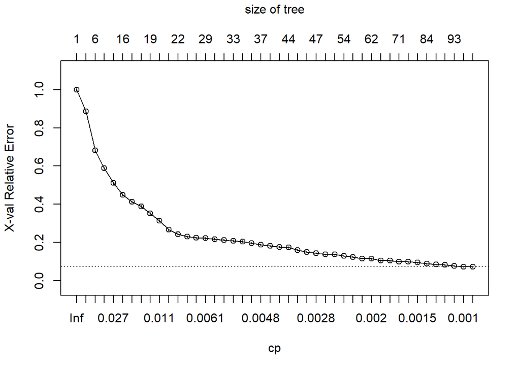

[figure not shown]

# predicting Test dataset with Decision Tree model

```
## Confusion Matrix and Statistics
##
##           Reference
## Prediction    A    B    C    D    E
##          A 2213   20    3   22    2
##          B   10 1421   31   25   42
##          C    0   39 1304   38    5
##          D    0    8   18 1184   23
##          E    9   30   12   17 1370
##
## Overall Statistics
##
##                Accuracy : 0.9549
##                  95% CI : (0.9501, 0.9594)
##     No Information Rate : 0.2845
##     P-Value [Acc > NIR] : < 2.2e-16
##
##                   Kappa : 0.9429
##  Mcnemar's Test P-Value : 2.676e-08
##
## Statistics by Class:
##
##                      Class: A Class: B Class: C Class: D Class: E
## Sensitivity            0.9915   0.9361   0.9532   0.9207   0.9501
## Specificity            0.9916   0.9829   0.9873   0.9925   0.9894
## Pos Pred Value         0.9792   0.9294   0.9408   0.9603   0.9527
## Neg Pred Value         0.9966   0.9846   0.9901   0.9846   0.9888
## Prevalence             0.2845   0.1935   0.1744   0.1639   0.1838
## Detection Rate         0.2821   0.1811   0.1662   0.1509   0.1746
## Detection Prevalence   0.2880   0.1949   0.1767   0.1572   0.1833
## Balanced Accuracy      0.9916   0.9595   0.9703   0.9566   0.9697
```

## Prediction Model Building with Random Forest

```
##
## Call:
##  randomForest(x = x, y = y, mtry = param$mtry)
##                Type of random forest: classification
##                      Number of trees: 500
## No. of variables tried at each split: 28
##
##         OOB estimate of  error rate: 0.26%
## Confusion matrix:
##      A    B    C    D    E  class.error
## A 3346    1    0    0    1 0.0005973716
## B    7 2270    2    0    0 0.0039491005
## C    0    4 2050    0    0 0.0019474197
## D    0    0    8 1921    1 0.0046632124
## E    0    0    0    7 2158 0.0032332564
```

# predict the Test dataset with Random Forest Model

```
## Confusion Matrix and Statistics
##
##           Reference
## Prediction    A    B    C    D    E
##          A 2232    2    0    0    0
##          B    0 1512    2    0    2
##          C    0    4 1366   10    0
##          D    0    0    0 1275    3
##          E    0    0    0    1 1437
##
## Overall Statistics
##
##                Accuracy : 0.9969
##                  95% CI : (0.9955, 0.998)
##     No Information Rate : 0.2845
##     P-Value [Acc > NIR] : < 2.2e-16
##
##                   Kappa : 0.9961
##  Mcnemar's Test P-Value : NA
##
## Statistics by Class:
##
##                      Class: A Class: B Class: C Class: D Class: E
## Sensitivity            1.0000   0.9960   0.9985   0.9914   0.9965
## Specificity            0.9996   0.9994   0.9978   0.9995   0.9998
## Pos Pred Value         0.9991   0.9974   0.9899   0.9977   0.9993
## Neg Pred Value         1.0000   0.9991   0.9997   0.9983   0.9992
## Prevalence             0.2845   0.1935   0.1744   0.1639   0.1838
## Detection Rate         0.2845   0.1927   0.1741   0.1625   0.1832
## Detection Prevalence   0.2847   0.1932   0.1759   0.1629   0.1833
## Balanced Accuracy      0.9998   0.9977   0.9982   0.9955   0.9982
```

## Predicting testing dataset with the Random Forest Model

```
##  [1] B A B A A E D B A A B C B A E E A B B B
## Levels: A B C D E
```